[figure not shown]

# RAADS Grad School Survey

This year, we sent around a brief survey to better inform the annual RAADS grad school panel. The reults of the survey are presented below.

```r
options(scipen = 999)

library(tidyverse)
library(urbnthemes)

set_urbn_defaults("print")

# load data
source("code/analyze-survey-data.R")
```

### Degrees

Of the four degrees listed on the survey, master’s degree was the most common degree selected. There was one response outside the set answers, expresseing interest in learning about certificates that could be earned while working at Urban.

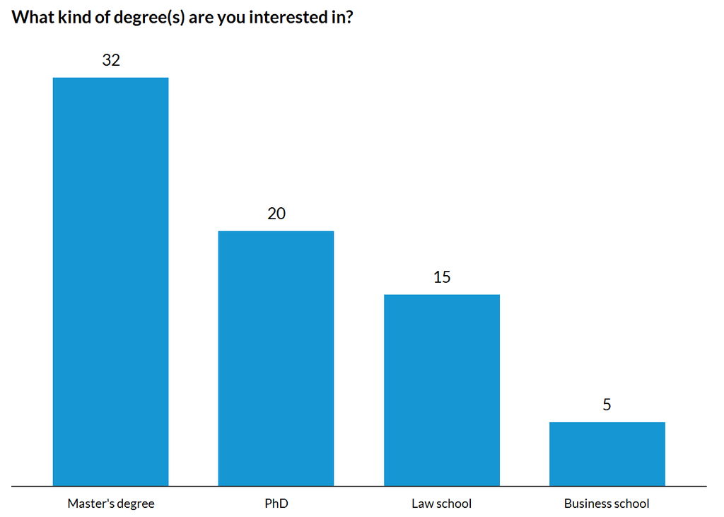

```r
response_data %>%
  filter(question == "degree") %>%
  ggplot(mapping = aes(x = reorder(response, desc(n)), y = n)) +
  geom_col() +
  geom_text(mapping = aes(label = n),
            vjust = -1, size = 4) +
  scale_y_continuous(expand = expand_scale(mult = c(0, .1))) +
  urbnthemes::remove_axis() +
  labs(x = NULL, y = NULL,
       title = "What kind of degree(s) are you interested in?")
```

### Fields

Public policy or public administration was the most common field RAADS were interested in. 31 of 41 total respondents selected it. Second and third place went to Sociology and Economics.

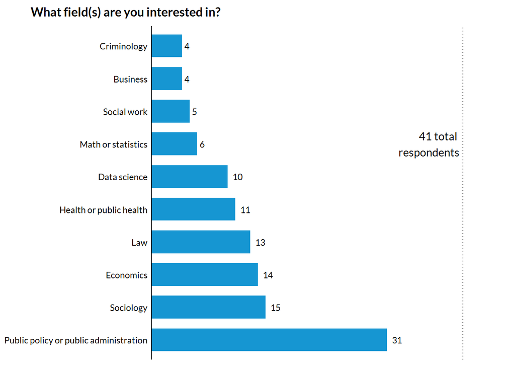

```r
annotation_text <- paste0(mean(response_data$total),
                          " total \n respondents")

response_data %>%
  filter(question == "field") %>%
  ggplot(mapping = aes(x = reorder(response, desc(n)), y = n)) +
  geom_col() +
  geom_text(mapping = aes(label = n),
            hjust = -.5, size = 3) +
  scale_y_continuous(expand = expand_scale(mult = c(0, .1)),
                     limits = c(0, 42)) +
  geom_hline(aes(yintercept = total),
             linetype = "dotted") +
  annotate(geom = "text", x = "Math or statistics",
           y = mean(response_data$total) - .5,
           label = annotation_text,
           hjust = 1) +
  coord_flip() +
  remove_axis(axis = "x", flip = TRUE) +
  labs(x = NULL, y = NULL,
       title = "What field(s) are you interested in?") +
  theme(plot.title = element_text(hjust = -.75))
```

### Process

The survey asked which parts of the process respondents would like advice on. Most RAADS indicated that they were looking for advice on picking a program.

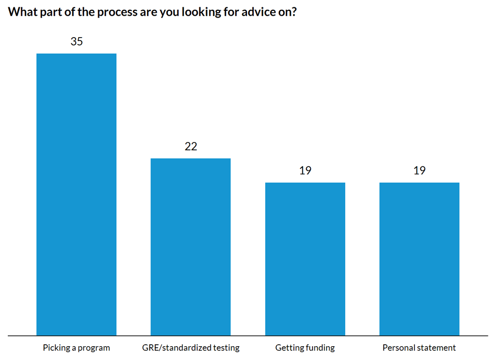

```r
response_data %>%
  filter(question == "process") %>%
  ggplot(mapping = aes(x = reorder(response, desc(n)), y = n)) +
  geom_col() +
  geom_text(mapping = aes(label = n),
            vjust = -1, size = 4) +
  scale_y_continuous(expand = expand_scale(mult = c(0, .1))) +
  urbnthemes::remove_axis() +
  labs(x = NULL, y = NULL,
       title = "What part of the process are you looking for advice on?")
```

### Other

The following comments were added in addition to the questions posed:

```r
# make vector of other responses
other <- c(
  data %>%
  filter(!is.na(other),
         other != "nope") %>%
  pull(other),
  "Financial trade-offs between stopping work and the value of the degree")

# this is to make sure we use the right number of bullets
length(other)
```

- Someone accepted to an Econ PhD
- How they decided when it was time to leave
- More on the differences between different graduate programs and how to decide which is right for you, because last year felt more like an instruction on how to apply rather than how to decide. Thanks!
- It would be so useful to have a database of the programs people at Urban have attended so that anyone interested in those programs could reach out and learn more.
- I would love if part of the panel broke down the different kinds of programs and how they relate to their future goals!
- Hearing from research analysts or research associates who already have masters or PHDs but are still pretty early on in their careers would be really helpful
- How they were able to talk about/characterize their work experience at Urban for non-research intensive programs.
- Financial trade-offs between stopping work and the value of the degree